# Projet Clustering & Modèles de mélange

```
                    Douaa BENHADDOUCHE - Lilia HARIRECHE - Antoine RODRIGUEZ

                                          MLDS FA
```

L’objectif de ce projet est de mettre en pratique différentes méthodes et packages de clustering permettant de partitionner correctement des jeux de données de grande dimension.

Pour cela nous allons utiliser les packages: **NbClust**, **mclust**, **Rmixmod**, ainsi appliquer plusieurs méthodes, algorithmes et fonctions sur les 5 jeux de données décrits ci-dessous.

## **1. Description des tables de données d’image**

- Japanese Female Facial Expressers dataset (JAFFE): contient 213 images de 7 expressions faciales posées par 10 modèles féminins japonais. Chaque image est composée de 676 pixels, et labelisée en fonction de la personne photographiée, et donc nombre de classes égale à 10.
- Modified ou Mixed National Institute of Standards and Technology dataset (MNIST): est une base de données de chiffres écrits à la main, elle comporte un ensemble de 3495 exemples avec 784 variables. Chaque image est de 28*28 pixelset en niveaux de gris.
- MFEA: ce jeu de données contient 2000 avec 241 variables.
- US Postal Service dataset (USPS): L’ensemble de données fait référence aux données numériques obtenues à partir du balayage des chiffres manuscrits à partir des enveloppes par le service postal des États-Unis. Il contient 9298 images dont 7291 train and 2007 test, avec 256 variables. Chaque image est de 16*16 pixels et en niveaux de gris.
- Optical recognition of handwritten digits data set (OPTIDIGITS): une base de données de chiffres manuscrits qui comporte 5620 images de chiffres et 64 variables. Chaque image est de 8*8 pixels et en niveaux de gris.

## **2. Chargement des tables**

```r
#load datasets
setwd("C:/Users/rodri/Desktop/TRAVAUXENCOURS/__Projet_MixtCoclust")
jaffe = readMat("jaffe.mat")
MNIST = readMat("MNIST5.mat")
MFEA = readMat("MFEAT1.mat")
optidigits = readMat("Optdigits.mat")
USPS = readMat("USPS.mat")
```

```r
# convert .Mat datasets to datafames
# JAFFE
data.jaffe =lapply(jaffe, unlist, use.names=FALSE)
data.jaffe = as.data.frame(data.jaffe$X)
class = as.factor(t(as.data.frame(jaffe$y)))
data.jaffe = data.frame(jaffe$X,class)

# MNIST
data.MNIST =lapply(MNIST, unlist, use.names=FALSE)
data.MNIST = as.data.frame(data.MNIST$X)
class = as.factor(t(as.data.frame(MNIST$y)))
data.MNIST = data.frame(MNIST$X,class)

# MFEA
data.MFEA =lapply(MFEA, unlist, use.names=FALSE)
data.MFEA = as.data.frame(data.MFEA$X)
class = as.factor(t(as.data.frame(MFEA$y)))
data.MFEA = data.frame(MFEA$X,class)

# USPS
data.USPS =lapply(USPS, unlist, use.names=FALSE)
data.USPS = as.data.frame(data.USPS$X)
class = as.factor(t(as.data.frame(USPS$y)))
data.USPS = data.frame(USPS$X,class)

# OPTIDIGITS
data.optidigits =lapply(optidigits, unlist, use.names=FALSE)
data.optidigits = as.data.frame(data.optidigits$X)
class = as.factor(t(as.data.frame(optidigits$y)))
data.optidigits = data.frame(optidigits$X,class)
rm(class)
```

## **3. Analyse en composantes principales**

Afin de visualiser les datasets ci dessus sur les deux plans factoriels, nous allons appliquer l’ACP.

```r
#jaffe
pca.jaffe = PCA(data.jaffe, ncp=2, quali.sup = 677, graph = FALSE)
plot(pca.jaffe, habillage=677, title = "PCA des individus de JAFFE")

#MNIST
pca.MNIST = PCA(data.MNIST, ncp=2, quali.sup = 785, graph= FALSE)
plot(pca.MNIST, habillage=785, title = "PCA des individus de MNIST")

#MFEA
pca.MFEA = PCA(data.MFEA, ncp=2, quali.sup = 241, graph= FALSE)
plot(pca.MFEA, habillage=241, title = "PCA des individus de MFEA")

#USPS
pca.USPS = PCA(data.USPS, ncp=2, quali.sup = 257, graph = FALSE)
plot(pca.USPS, habillage=257, title = "PCA des individus de USPS")

#OPTIDIGITS
pca.optidigits = PCA(data.optidigits, ncp=2, quali.sup = 65, graph = FALSE)
plot(pca.optidigits, habillage=65, title = "PCA des individus de OPTIDIGITS")
```

[output not shown]

- sur le dataset *JAFFE*, les classes sont bien distinguées, elles sont linéairement séparables.
- Toutefois sur les autres jeux de données, nous remarquons qu’il est impossible de distinguées les classes, elles ne sont pas linéairement séparables, car l’ACP n’est pas adaptée aux datasets à grande dimension et contenant des données sparse.

## **4. Recherche du nombre de clusters : NbClust**

Nous voulons partitionner l’ensemble des observations, pour cela nous allons utiliser le package **Nbclust** pour réaliser un **kmeans** et des **CAH** avec différents critères d’agrégation.

**NOTE IMPORTANTE** Comme la nature des datasets est similaire, on se propose dans la suite de ne présenter qu’uniquement les codes d’execution des méthodes pour le dataset JAFFE, les affichages seront quand à eux bien évidemment présents:

```r
set.seed(42)
# jaffe kmeans
km.jaffe=NbClust(data.jaffe[,!colnames(data.jaffe)=='class'], method = "kmeans",
                 distance = "euclidean", index = "silhouette",min.nc = 5, max.nc = 30)

# jaffe CAH WARD
ward.jaffe=NbClust(data.jaffe[,-677], method = "ward.D",
                   index = "silhouette",min.nc = 5,  max.nc = 30)

# jaffe CAH AVERAGE
average.jaffe=NbClust(data.jaffe[,-677], method = "average",index ="silhouette",
                      min.nc = 5, max.nc = 30)

# jaffe CAH SINGLE
single.jaffe=NbClust(data.jaffe[,-677], method = "single",index = "silhouette",
                     min.nc = 5, max.nc = 30)

# jaffe complete
complete.jaffe=NbClust(data.jaffe[,-677], method = "complete",index = "silhouette",
                       min.nc = 5, max.nc = 30)
```

On sauvegarde les résultats : (de la même manières pour les 4 autres datasets)

```r
saveRDS(km.jaffe, "resultats/km.jaffe")
saveRDS(ward.jaffe, "resultats/ward.jaffe")
saveRDS(average.jaffe, "resultats/average.jaffe")
saveRDS(single.jaffe, "resultats/single.jaffe")
saveRDS(complete.jaffe, "resultats/complete.jaffe")
```

### Affichages des nombres de classes

Affichage de nombre de classes trouvées par les différents algorithmes :

```r
print(km.jaffe$Best.nc[1])
```

```
## Number_clusters
##              17
```

```r
print(ward.jaffe$Best.nc[1])
```

```
## Number_clusters
##              20
```

```r
print(average.jaffe$Best.nc[1])
```

```
## Number_clusters
##              30
```

```r
print(single.jaffe$Best.nc[1])
```

```
## Number_clusters
##              30
```

```r
print(complete.jaffe$Best.nc[1])
```

```
## Number_clusters
##              28
```

Affichage des partitions:

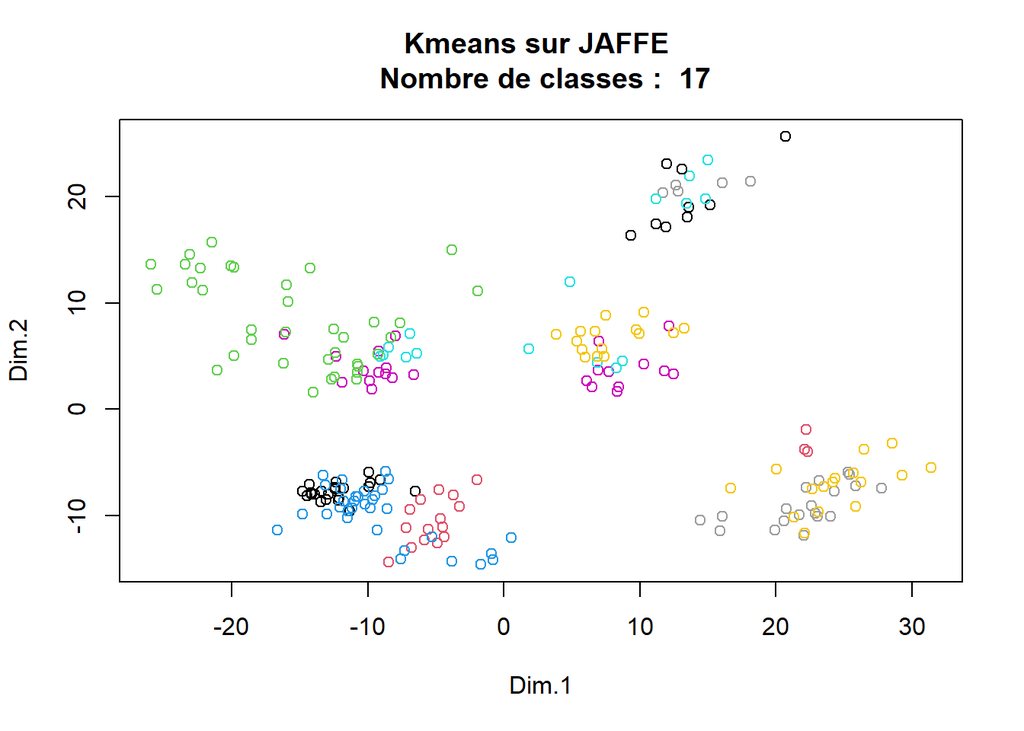

```r
plot(pca.jaffe$ind$coord,col=km.jaffe$Best.partition,
     main = paste("Kmeans sur JAFFE \n Nombre de classes : ", km.jaffe$Best.nc[1]))
```

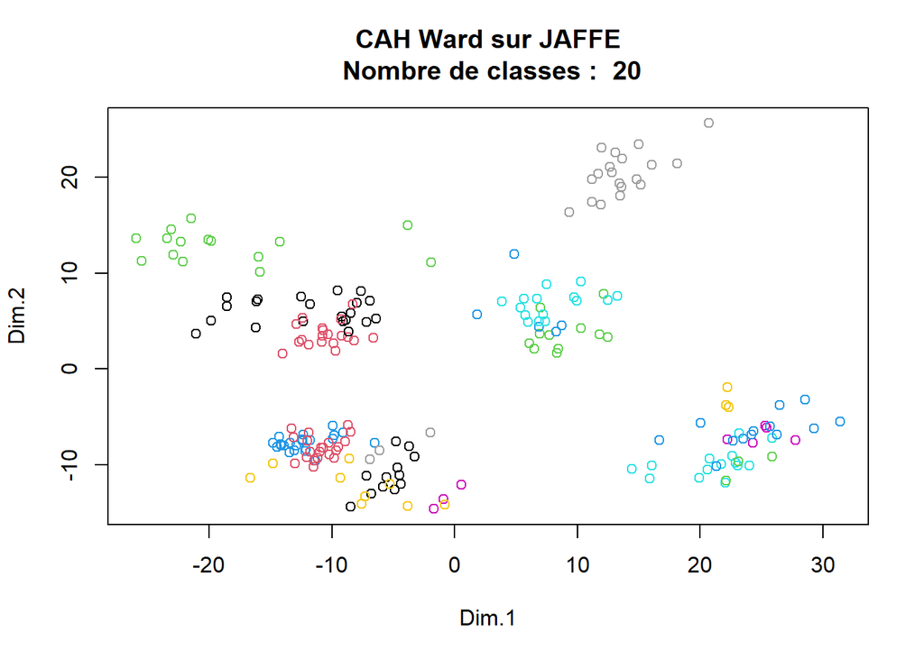

```r
plot(pca.jaffe$ind$coord,col=ward.jaffe$Best.partition,
     main = paste("CAH Ward sur JAFFE\n Nombre de classes : ", ward.jaffe$Best.nc[1]))
```

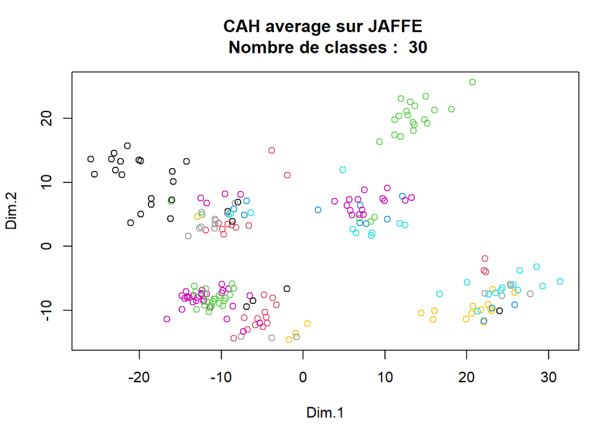

```r
plot(pca.jaffe$ind$coord,col=average.jaffe$Best.partition,
     main = paste("CAH average sur JAFFE \n Nombre de classes : ", average.jaffe$Best.nc[1]))
```

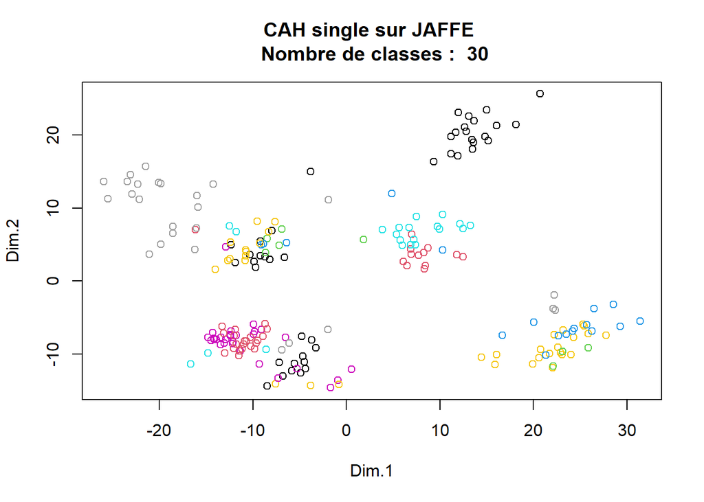

```r
plot(pca.jaffe$ind$coord,col=single.jaffe$Best.partition,
     main = paste("CAH single sur JAFFE \n Nombre de classes : ", single.jaffe$Best.nc[1]))
```

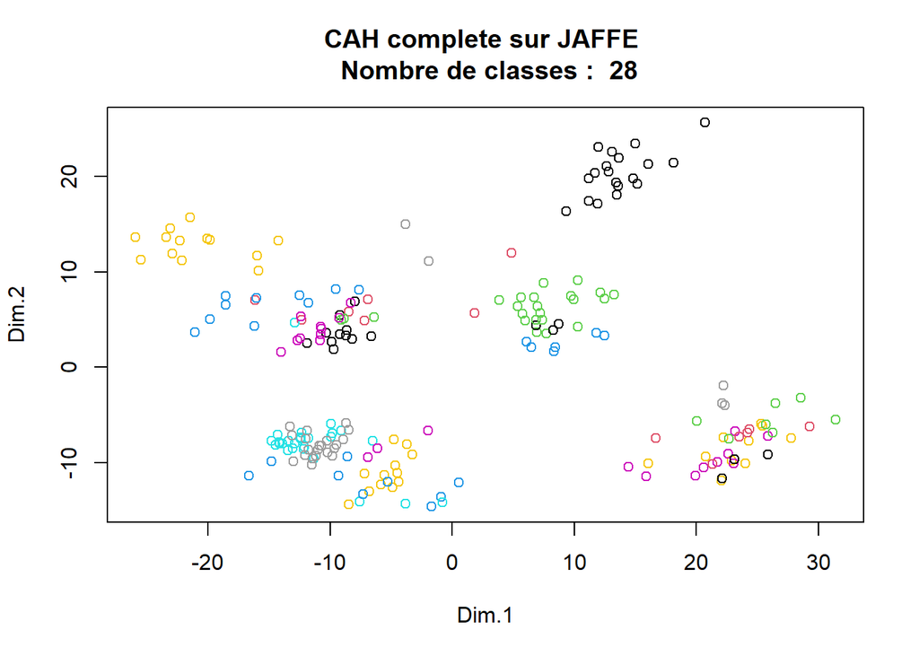

```r
plot(pca.jaffe$ind$coord,col=complete.jaffe$Best.partition,
     main = paste("CAH complete sur JAFFE \n Nombre de classes : ", complete.jaffe$Best.nc[1]))
```

### Consensus

Pour réaliser un consensus des 5 différentes partitions trouvées (pour chacun des 5 datasets), nous pourrions utiliser les fonction `cl_ensemble` et `cl_consensus` du package `clue` :

```r
# création de l'objet cluster ensemble
NbClust_results <-list(km.jaffe$Best.partition, ward.jaffe$Best.partition,
                       average.jaffe$Best.partition, single.jaffe$Best.partition,
                       complete.jaffe$Best.partition)
names(NbClust_results) <- c('kmeans','ward','average','single','complete')
ens <- cl_ensemble(NbClust_results)
```

On obtiendrait alors le consensus de clustering avec la fonction :

```r
cl_consensus(ens)
```

Or l’objet renvoyé par `NbClust` ne contient pas une partition au sens du package `clue` :

```r
is.cl_partition(NbClust_results) # renvoie FALSE
```

Une partition en ce sens est un tableau contenant la probabilité pour chaque individus d’apartenir à une classe.

(Voir 2.1.1 dans https://mirror.las.iastate.edu/CRAN/web/packages/clue/vignettes/clue.pdf )

### Autres datasets

Le détail des autres datasets est disponible dans l’annexe de la question 4.

## **5. Clustering à partir des deux premières composantes ACP: utiliser HCPC**

```r
hcpcward.jaffe = HCPC(pca.jaffe, nb.clust = -1, method = "ward", graph=FALSE)

hcpccomp.jaffe = HCPC(pca.jaffe, nb.clust = -1, method = "complete", graph=FALSE)

hcpcsingle.jaffe = HCPC(pca.jaffe, nb.clust = -1, method = "single", graph=FALSE)

hcpcav.jaffe = HCPC(pca.jaffe, nb.clust = -1, method = "average", graph=FALSE)
```

```r
print(length(unique(hcpcward.jaffe)))
```

```
## [1] 4
```

```r
print(length(unique(hcpcav.jaffe)))
```

```
## [1] 3
```

```r
print(length(unique(hcpcsingle.jaffe)))
```

```
## [1] 3
```

```r
print(length(unique(hcpccomp.jaffe)))
```

```
## [1] 4
```

### Autres datasets

```r
# Affichage du nombres de partitions pour chacune des méthodes appliquées à MNIST
print(length(unique(hcpcward.MNIST)))
```

```
## [1] 3
```

```r
print(length(unique(hcpcav.MNIST)))
```

```
## [1] 3
```

```r
print(length(unique(hcpcsingle.MNIST)))
```

```
## [1] 3
```

```r
print(length(unique(hcpccomp.MNIST)))
```

```
## [1] 3
```

```r
# Affichage du nombres de partitions pour chacune des méthodes appliquées à MFEA
print(length(unique(hcpcward.MFEA)))
```

```
## [1] 3
```

```r
print(length(unique(hcpcav.MFEA)))
```

```
## [1] 3
```

```r
print(length(unique(hcpcsingle.MFEA)))
```

```
## [1] 3
```

```r
print(length(unique(hcpccomp.MFEA)))
```

```
## [1] 3
```

```r
# Affichage du nombres de partitions pour chacune des méthodes appliquées à USPS
print(length(unique(hcpcward.USPS)))
```

```
## [1] 4
```

```r
print(length(unique(hcpcav.USPS)))
```

```
## [1] 3
```

```r
print(length(unique(hcpcsingle.USPS)))
```

```
## [1] 3
```

```r
print(length(unique(hcpccomp.USPS)))
```

```
## [1] 3
```

```r
# Affichage du nombres de partitions pour chacune des méthodes appliquées à optidigits
print(length(unique(hcpcward.optidigits)))
```

```
## [1] 3
```

```r
print(length(unique(hcpcav.optidigits)))
```

```
## [1] 3
```

```r
print(length(unique(hcpcsingle.optidigits)))
```

```
## [1] 3
```

```r
print(length(unique(hcpccomp.optidigits)))
```

```
## [1] 3
```

## **6. Comparaison des partitions: matrices de confusion**

```r
#jaffe
table(km.jaffe$Best.partition,data.jaffe$class)
```

```
##
##       1  2  3  4  5  6  7  8  9 10
##   1   0  0  0  6  0  0  0  0  0  0
##   2   0  0  0  0  0  0  0 15  0  0
##   3   0  0  0  0  0 21  0  0  0  0
##   4   0  0  0  0  0  0  0  6  0  6
##   5   0  0  0  0  6  0  5  0  0  0
##   6  11  0  0  0  0  0  0  0  0  0
##   7   0  0  0  0  0  0  0  0  0 16
##   8   0  0 19  0  0  0  0  0  0  0
##   9   0  0  0  3  0  0  0  0  0  0
##   10  0  0  3  0  0  0  0  0  0  0
##   11  0  0  0  0 15  0  0  0  0  0
##   12  0  0  0  0  0  0  0  0 21  0
##   13  0  0  0  5  0  0  0  0  0  0
##   14 12  0  0  1  0  0  0  0  0  0
##   15  0  0  0  0  0  0 15  0  0  0
##   16  0  0  0  5  0  0  0  0  0  0
##   17  0 22  0  0  0  0  0  0  0  0
```

```r
table(ward.jaffe$Best.partition,data.jaffe$class)
```

```
##
##       1  2  3  4  5  6  7  8  9 10
##   1   4  0  0  1  4  6  0  0  0  0
##   2   8  0  0  0  0  0  0  0  0  0
##   3  11  0  0  0  0  0  0  0  0  0
##   4   0 22  0  0  0  0  0  0  0  0
##   5   0  0 14  0  0  0  0  0  0  0
##   6   0  0  5  0  0  0  0  0  0  0
##   7   0  0  3  0  0  0  0  0  0  0
##   8   0  0  0 19  0  0  0  0  0  0
##   9   0  0  0  0  6  0  0  0  0  0
##   10  0  0  0  0 11  0  0  0  0  0
##   11  0  0  0  0  0 15  0  0  0  0
##   12  0  0  0  0  0  0  5  0  0  0
##   13  0  0  0  0  0  0 15  0  0  0
##   14  0  0  0  0  0  0  0  3  0  0
##   15  0  0  0  0  0  0  0  3  0  6
##   16  0  0  0  0  0  0  0  3  0  0
##   17  0  0  0  0  0  0  0 12  0  0
##   18  0  0  0  0  0  0  0  0 21  0
##   19  0  0  0  0  0  0  0  0  0  3
##   20  0  0  0  0  0  0  0  0  0 13
```

```r
table(hcpcward.jaffe, data.jaffe$class)
```

```
##
## hcpcward.jaffe  1  2  3  4  5  6  7  8  9 10
##              1 12  0  0  1 21 20  0  0  0  0
##              2  0 22  0  0  0  0  0 21 21  6
##              3 11  0  0 19  0  1 20  0  0  0
##              4  0  0 22  0  0  0  0  0  0 16
```

```r
table(average.jaffe$Best.partition,data.jaffe$class)
```

```
##
##       1  2  3  4  5  6  7  8  9 10
##   1   3  0  0  0  0  0  0  0  0  0
##   2   8  0  0  0  0  0  0  0  0  0
##   3   1  0  0  1  0  0  0  0  0  0
##   4   5  0  0  0  0  0  0  0  0  0
##   5   6  0  0  0  0  0  0  0  0  0
##   6   0 22  0  0  0  0  0  0  0  0
##   7   0  0 13  0  0  0  0  0  0  0
##   8   0  0  5  0  0  0  0  0  0  0
##   9   0  0  1  0  0  0  0  0  0  0
##   10  0  0  3  0  0  0  0  0  0  0
##   11  0  0  0 19  0  0  0  0  0  0
##   12  0  0  0  0  3  0  0  0  0  0
##   13  0  0  0  0  3  0  0  0  0  0
```

[output cut: 17 more lines]

```r
table(hcpcav.jaffe, data.jaffe$class)
```

```
##
## hcpcav.jaffe  1  2  3  4  5  6  7  8  9 10
##            1 12 22  0  1 21 19  0 21 21  6
##            2 11  0  0 19  0  2 20  0  0  0
##            3  0  0 22  0  0  0  0  0  0 16
```

```r
table(single.jaffe$Best.partition,data.jaffe$class)
```

```
##
##       1  2  3  4  5  6  7  8  9 10
##   1  11  0  0  0  0  0  0  0  0  0
##   2   9  0  0  0  0  0  0  0  0  0
##   3   1  0  0  0  0  0  0  0  0  0
##   4   1  0  0  0  0  0  0  0  0  0
##   5   1  0  0  0  0  0  0  0  0  0
##   6   0 22  0  0  0  0  0  0  0  0
##   7   0  0 19  0  0  0  0  0  0  0
##   8   0  0  3  0  0  0  0  0  0  0
##   9   0  0  0 19  0  0  0  0  0  0
##   10  0  0  0  1  0  0  0  0  0  0
##   11  0  0  0  0  3  0  0  0  0  0
##   12  0  0  0  0  3  0  0  0  0  0
##   13  0  0  0  0  2  0  0  0  0  0
```

[output cut: 17 more lines]

```r
table(hcpcsingle.jaffe, data.jaffe$class)
```

```
##
## hcpcsingle.jaffe  1  2  3  4  5  6  7  8  9 10
##                1 12 22  0  1 21 19  0 21 21  6
##                2 11  0  0 19  0  2 20  0  0  0
##                3  0  0 22  0  0  0  0  0  0 16
```

```r
table(complete.jaffe$Best.partition,data.jaffe$class)
```

```
##
##       1  2  3  4  5  6  7  8  9 10
##   1  11  0  0  0  0  0  0  0  0  0
##   2   1  0  0  1  0  0  0  0  0  0
##   3   5  0  0  0  0  0  0  0  0  0
##   4   6  0  0  0  0  0  0  0  0  0
##   5   0 22  0  0  0  0  0  0  0  0
##   6   0  0  9  0  0  0  0  0  0  0
##   7   0  0 10  0  0  0  0  0  0  0
##   8   0  0  3  0  0  0  0  0  0  0
##   9   0  0  0 19  0  0  0  0  0  0
##   10  0  0  0  0  3  0  0  0  0  0
##   11  0  0  0  0  3  0  0  0  0  0
##   12  0  0  0  0  4  6  0  0  0  0
##   13  0  0  0  0  1  0  0  0  0  0
##   14  0  0  0  0 10  0  0  0  0  0
##   15  0  0  0  0  0 13  0  0  0  0
##   16  0  0  0  0  0  2  0  0  0  0
##   17  0  0  0  0  0  0  3  0  0  0
##   18  0  0  0  0  0  0  2  0  0  0
##   19  0  0  0  0  0  0 15  0  0  0
##   20  0  0  0  0  0  0  0  3  0  0
##   21  0  0  0  0  0  0  0  3  0  0
##   22  0  0  0  0  0  0  0  3  0  0
##   23  0  0  0  0  0  0  0 12  0  0
##   24  0  0  0  0  0  0  0  0 21  0
##   25  0  0  0  0  0  0  0  0  0  3
##   26  0  0  0  0  0  0  0  0  0  6
##   27  0  0  0  0  0  0  0  0  0  7
##   28  0  0  0  0  0  0  0  0  0  6
```

```r
table(hcpccomp.jaffe, data.jaffe$class)
```

```
##
## hcpccomp.jaffe  1  2  3  4  5  6  7  8  9 10
##              1 12  0  0  1 21 20  0  0  0  0
##              2  0 22  0  0  0  0  0 21 21  6
##              3 11  0  0 19  0  1 20  0  0  0
##              4  0  0 22  0  0  0  0  0  0 16
```

Les autres tables ont été calculsées sur `Annexe_codes_autres_datasets.Rmd`

## **7. Algorithme EM pour l’approche mélange**

On applique les packages Rmixmod et Mclust pour cette approche en utilisant l’algorithme EM:

```r
# Rmixmod
pc.jaffe = prcomp(data.jaffe[,!colnames(data.jaffe)=='class'])

# definition d'une stratégie nécessaire
strategie = mixmodStrategy(algo="EM", initMethod="smallEM",
                         nbTry=10, epsilonInInit=0.00001)
em_mix.jaffe = mixmodCluster(data=as.data.frame(pc.jaffe$x[,1:10]), nbCluster=10,
                        strategy=strategie, dataType="quantitative",
                        models=mixmodGaussianModel(listModels=c("Gaussian_p_Lk_C")))
```

```r
# Mclust
em_mc.jaffe = Mclust(data = pc.jaffe$x[,1:10], G=10, verbose=FALSE)
```

Nous aurions pu utiliser `pca.jaffe` et mais nous n’avions gardé que les 2 premières composantes principales donc nous avons préféré garder une PCA plus complète avec ses 10 premières composantes.

```r
em_mc.jaffe = Mclust(data = pca.jaffe$var$coord, G=10, verbose=FALSE)
```

On choisit d’enregistrer uniquement les partitions :

```r
saveRDS(em_mix.jaffe@bestResult@partition, "resultats/em_mix.jaffe")
saveRDS(em_mc.jaffe$classification, "resultats/em_mc.jaffe")
```

### **8.**

```r
cm = table(em_mix.jaffe@bestResult@partition, em_mc.jaffe$classification)
lin_assignement = solve_LSAP(cm, maximum=TRUE)
cm = table(lin_assignement[em_mix.jaffe@bestResult@partition],
           em_mc.jaffe$classification)
cm
```

```
##
##       1  2  3  4  5  6  7  8  9 10
##   1  23  0  0  0  0  0  0  0  0  0
##   2   0 22  0  0  0  0  0  0  0  0
##   3   3  0 19  0  0  0  0  0  0  0
##   4   0  0  0 19  0  0  0  0  0  0
##   5   5  0  0  0 17  0  0  0  0  0
##   6   0  0  0  0  0 21  0  0  0  0
##   7   8  0  0  0  0  0 12  0  0  0
##   8  18  0  0  0  0  0  0  9  0  0
##   9   0  0  0  0  0  0  0  0 21  0
##   10  3  0  0  0  0  0  0  0  0 13
```

### **9.**

MclustDR est une méthode de réduction de dimension pour visualiser le clustering issu d’un mélange de densités gaussiennes.

```r
#jaffe1
mdr.jaffe = MclustDR(em_mc.jaffe)
plot(mdr.jaffe)
```

[output not shown]

## **10. Etude comparative entre les résultats des différents algorithmes**

Utilisons la librairie `aricode` pour calculer les indices NMI et ARI de chacunes des méthodes décrites plus tôt.

L’indice NMI mesure l’information mutuelle et tends à être grande quand le clustering est bon. L’ARI mesure l’indice de Rand entre deux partitions, qui est n’est autre qu’une mesure de similarité : plus celui-ci est grand, plus deux partitions sont proches au sens de cette mesure.

On définit une fonction calculant le taux de mauvais classement pour chacune des méthodes :

```r
library(clue) # solve_LSAP
bad_ratio <- function(predicted.labels, true.labels){
  # -------
  # predicted.labels : labels found with clustering method
  # -------
  cm = table(predicted.labels, true.labels)
  lin_assignement = solve_LSAP(cm, maximum=TRUE) # réalise algorithme hongrois
  # pour maximiser la diagonale  http://search.r-project.org/library/clue/html/solve_LSAP.html
  cm = table(lin_assignement[predicted.labels], true.labels)

  ratio <- 1 - sum(diag(cm))/length(predicted.labels)
  return(ratio)
}
```

Ainsi qu’une fonction qui va créer les tableaux récapitulatifs de chacuns des indices pour chaque méthode (avec le vrai nombre de classe) et chaque dataset.

Les tableaux `nommethode_10.nomtablea` ont été calculés et enregistrés via la fonction `apply_clustering()` suivante :

```r
library(iterators)
# function to create row of a dataframe with a certain indicator (bad-ratio,NMI and ARI)
apply_clustering <- function(data, pca.data, mc.data, mix.data, rowname){
  # -------
  # data : original data, pca.data : PCA on data
  # mc.data : EM with mclust on data  (em_mc.X)
  # mix.data : EM with Rmixmod on data (em_mix.X)
  # rowname : name of data, fun_indice : function bad_radio, aricode::NMI or aricode::ARI
  # -------
  # init data.frame

  # for printing progress
  iterator = iter(seq(1, 11, length.out = 11))
  progress <- function(){cat(nextElem(iterator), "/11\r") ; flush.console()}
  # ----

  tmc = data.frame(rownames=rowname)
  nmi = data.frame(rownames=rowname)
  ari = data.frame(rownames=rowname)
  results.data <- NbClust(data[,!colnames(data)=='class'], method = "kmeans",
                         distance = "euclidean", index = "silhouette",
                         min.nc = 10, max.nc = 10)
  # remplissage des tableaux
  tmc$kmeans = bad_ratio(results.data$Best.partition, data$class)
  nmi$kmeans = NMI(results.data$Best.partition, data$class)
  ari$kmeans = ARI(results.data$Best.partition, data$class)
  # enregistrement de la partition
  saveRDS(results.data$Best.partition, paste('resultats/km_10.', rowname, sep=""))
  progress() # affiche la progression


  # la suite est similaire pour les autres méthodes :
  # ------
  results.data <- NbClust(data[,!colnames(data)=='class'], method="ward.D",
                         index="silhouette", min.nc=10,  max.nc=10)
  tmc$ward = bad_ratio(results.data$Best.partition, data$class)
  nmi$ward = NMI(results.data$Best.partition, data$class)
  ari$ward = ARI(results.data$Best.partition, data$class)
  saveRDS(results.data$Best.partition, paste('resultats/ward_10.', rowname, sep=""))
  progress()

  results.data <- NbClust(data[,!colnames(data)=='class'], method="average",
                         index="silhouette", min.nc=10,  max.nc=10)
  tmc$average = bad_ratio(results.data$Best.partition, data$class)
  nmi$average = NMI(results.data$Best.partition, data$class)
  ari$average = ARI(results.data$Best.partition, data$class)
  saveRDS(results.data$Best.partition, paste('resultats/average_10.', rowname, sep=""))
  progress()

  results.data <- NbClust(data[,!colnames(data)=='class'], method="single",
                         index="silhouette", min.nc=10,  max.nc=10)
  tmc$single = bad_ratio(results.data$Best.partition, data$class)
  nmi$single = NMI(results.data$Best.partition, data$class)
  ari$single = ARI(results.data$Best.partition, data$class)
  saveRDS(results.data$Best.partition, paste('resultats/single_10.', rowname, sep=""))
  progress()

  results.data <- NbClust(data[,!colnames(data)=='class'], method="complete",
                         index="silhouette", min.nc=10,  max.nc=10)
  tmc$complete = bad_ratio(results.data$Best.partition, data$class)
  nmi$complete = NMI(results.data$Best.partition, data$class)
  ari$complete = ARI(results.data$Best.partition, data$class)
  saveRDS(results.data$Best.partition, paste('resultats/complete_10.', rowname, sep=""))
  progress()

  results.data <- HCPC(pca.data, nb.clust=10, method="ward", graph=FALSE)
  tmc$HCPCward = bad_ratio(results.data$data.clust$clust, data$class)
  nmi$HCPCward = NMI(results.data$data.clust$clust, data$class)
  ari$HCPCward = ARI(results.data$data.clust$clust, data$class)
  saveRDS(results.data$data.clust$clust, paste('resultats/hcpcward_10.', rowname, sep=""))
  progress()

  results.data <- HCPC(pca.data, nb.clust=10, method="complete", graph=FALSE)
  tmc$HCPCcomplete = bad_ratio(results.data$data.clust$clust, data$class)
  nmi$HCPCcomplete = NMI(results.data$data.clust$clust, data$class)
  ari$HCPCcomplete = ARI(results.data$data.clust$clust, data$class)
  saveRDS(results.data$data.clust$clust, paste('resultats/hcpccomp_10.', rowname, sep=""))
  progress()

  results.data <- HCPC(pca.data, nb.clust=10, method="single", graph=FALSE)
  tmc$HCPCsingle = bad_ratio(results.data$data.clust$clust, data$class)
  nmi$HCPCsingle = NMI(results.data$data.clust$clust, data$class)
  ari$HCPCsingle = ARI(results.data$data.clust$clust, data$class)
  saveRDS(results.data$data.clust$clust, paste('resultats/hcpcsingle_10.', rowname, sep=""))
  progress()

  results.data <- HCPC(pca.data, nb.clust=10, method="average", graph=FALSE)
  tmc$HCPCaverage = bad_ratio(results.data$data.clust$clust, data$class)
  nmi$HCPCaverage = NMI(results.data$data.clust$clust, data$class)
  ari$HCPCaverage = ARI(results.data$data.clust$clust, data$class)
  saveRDS(results.data$data.clust$clust, paste('resultats/hcpcav_10.', rowname, sep=""))
  progress()
  # -----

  # on ne recalcule pas les EM qui sont déjà à 10 classes

  tmc$EMmc = bad_ratio(mc.data, data$class)
  nmi$EMmc = NMI(mc.data, data$class)
  ari$EMmc = ARI(mc.data, data$class)
  # déjà enregistré
  progress()

  tmc$EMrmixmod = bad_ratio(mix.data, data$class)
  nmi$EMrmixmod = NMI(mix.data, data$class)
  ari$EMrmixmod = ARI(mix.data, data$class)
  progress()
  return(list(tmc , nmi, ari))
}
```

```r
temp = apply_clustering(data.jaffe, pca.jaffe, em_mc.jaffe, em_mix.jaffe, 'jaffe')
df.tmc = temp[[1]]
df.nmi = temp[[2]]
df.ari = temp[[3]]

temp = apply_clustering(data.MNIST, pca.MNIST, em_mc.MNIST, em_mix.MNIST, 'MNIST')
# on concatene les tableaux par les lignes
df.tmc = rbind(df.tmc, temp[[1]])
df.nmi = rbind(df.nmi, temp[[2]])
df.ari = rbind(df.ari, temp[[3]])
# chaque ligne représentant un dataset

temp = apply_clustering(data.MFEA, pca.MFEA, em_mc.MFEA, em_mix.MFEA, 'MFEA')
df.tmc = rbind(df.tmc, temp[[1]])
df.nmi = rbind(df.nmi, temp[[2]])
df.ari = rbind(df.ari, temp[[3]])

temp = apply_clustering(data.USPS, pca.USPS, em_mc.USPS, em_mix.USPS, 'USPS')
df.tmc = rbind(df.tmc, temp[[1]])
df.nmi = rbind(df.nmi, temp[[2]])
df.ari = rbind(df.ari, temp[[3]])

temp = apply_clustering(data.optidigits, pca.optidigits, em_mc.optidigits,
                        em_mix.optidigits, 'optidigits')
df.tmc = rbind(df.tmc, temp[[1]])
df.nmi = rbind(df.nmi, temp[[2]])
df.ari = rbind(df.ari, temp[[3]])
```

```r
saveRDS(df.tmc, "resultats/df.tmc")
saveRDS(df.nmi, "resultats/df.nmi")
saveRDS(df.ari, "resultats/df.ari")
```

### **Visualisation des indices**

```r
# Taux de mauvais classement
df.tmc
```

```
##     rownames    kmeans      ward   average    single  complete  HCPCward
## 1      jaffe 0.2535211 0.1173709 0.4882629 0.6478873 0.4460094 0.3708920
## 2      MNIST 0.4792561 0.4329041 0.7782546 0.8858369 0.6978541 0.7127325
## 3       MFEA 0.2415000 0.1295000 0.5210000 0.8965000 0.5545000 0.4840000
## 4       USPS 0.3274898 0.2480103 0.7774790 0.8327597 0.5996989 0.6110992
## 5 optidigits 0.2074733 0.1649466 0.3651246 0.8971530 0.4950178 0.4870107
##   HCPCcomplete HCPCsingle HCPCaverage      EMmc  EMrmixmod
## 1    0.3521127  0.4741784   0.4835681 0.1737089 0.03286385
## 2    0.7175966  0.7138770   0.7164521 0.4540773 0.41230329
## 3    0.4880000  0.4840000   0.4760000 0.1995000 0.26100000
## 4    0.6094859  0.6091633   0.6110992 0.3049043 0.31565928
## 5    0.4809609  0.4870107   0.4873665 0.2265125 0.27597865
```

```r
# Indice ARI pour chacunes des méthodes
df.ari
```

```
##     rownames    kmeans      ward     average       single  complete  HCPCward
## 1      jaffe 0.6820343 0.7701080 0.341964574 1.468528e-01 0.4499918 0.5740438
## 2      MNIST 0.3532772 0.4544558 0.037372231 1.318960e-05 0.1182318 0.1324271
## 3       MFEA 0.6809902 0.7349105 0.463169025 7.197997e-06 0.2846244 0.3248743
## 4       USPS 0.5362237 0.6764475 0.007434392 4.098145e-06 0.1881273 0.2849420
## 5 optidigits 0.6718752 0.7638114 0.570252648 1.856392e-06 0.3607227 0.3247814
##   HCPCcomplete HCPCsingle HCPCaverage      EMmc EMrmixmod
## 1    0.5715286  0.4530918   0.4341506 0.6040168 0.9335409
## 2    0.1288175  0.1292899   0.1345402 0.4059126 0.4019157
## 3    0.3273270  0.3248743   0.3316227 0.6808312 0.5928354
## 4    0.2895704  0.2862830   0.2849420 0.5786065 0.5605548
## 5    0.3232294  0.3247814   0.3241408 0.6811190 0.5969662
```

```r
# Indice ARI pour chacunes des méthodes
df.nmi
```

```
##     rownames    kmeans      ward    average       single  complete  HCPCward
## 1      jaffe 0.8238341 0.8830157 0.60895297 0.3977141187 0.6613371 0.7447210
## 2      MNIST 0.4911924 0.5946189 0.12950380 0.0025886490 0.2891662 0.2000323
## 3       MFEA 0.7477758 0.7963121 0.58463137 0.0050109674 0.4697454 0.4809727
## 4       USPS 0.6121691 0.7726650 0.08074839 0.0009734116 0.3532185 0.3738643
## 5 optidigits 0.7489430 0.8338032 0.69527808 0.0017816590 0.5483787 0.4595675
##   HCPCcomplete HCPCsingle HCPCaverage      EMmc EMrmixmod
## 1    0.7341586  0.6634654   0.6690127 0.7991399 0.9625301
## 2    0.1940509  0.1965358   0.2032463 0.5631269 0.5338630
## 3    0.4876611  0.4809727   0.4900808 0.7606314 0.7023763
## 4    0.3765023  0.3747166   0.3738643 0.6934051 0.6541634
## 5    0.4518068  0.4595675   0.4595091 0.7826617 0.6941182
```

## **11.**

Appliquons l’algorithme t-SNE (*t-distributed stochastic neighbor embedding*) pour réduire la dimension et afficher les résultats de nos classes obtenues pour chaque méthode.

```r
tsne.jaffe=Rtsne(data.jaffe[,!colnames(data.jaffe)=='class'], dim=2, perplexity=50)
tsne.MNIST=Rtsne(data.MNIST[,!colnames(data.MNIST)=='class'], dim=2, perplexity=50)
# tsne.MFEA=Rtsne(data.MFEA[,!colnames(data.MFEA)=='class'], dim=2, perplexity=50)
tsne.USPS=Rtsne(data.USPS[,!colnames(data.USPS)=='class'], dim=2, perplexity=50)
tsne.optidigits=Rtsne(data.optidigits[,!colnames(data.optidigits)=='class'], dim=2, perplexity=50)
```

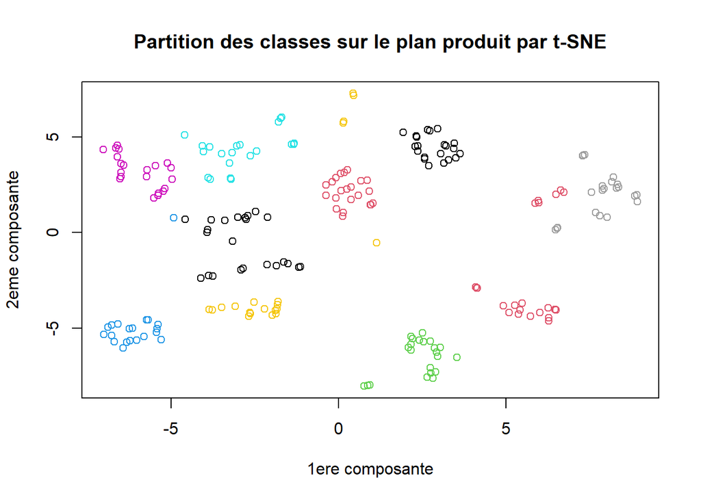

```r
plot_tsne <- function (tsne, predicted.classes, amain){
  plot(tsne$Y,
       col=predicted.classes,
       xlab="1ere composante",
       ylab="2eme composante",
       main=paste(amain, "sur le plan produit par t-SNE", sep=" "))
}

plot_tsne(tsne.jaffe, data.jaffe$class, amain="Partition des classes")
```

Les différentes visualisations sont représentées dans l’**annexe de la question 11** (excepté pour le dataset MFEA où nous n’avons pas pu réaliser la réduction t-SNE).

## **12. Reduction de dimension avec un auto-encoder**

On souhaite réduire la dimension de nos datasets à l’aide d’auto-encodeurs : nous utiliserons `python` pour entrainer les différents auto-encodeurs et récuperer les datasets réduits.

On enregistre d’abord les fichiers en `.csv` pour les lire plus facilement sur `python` :

```r
write.table(data.jaffe, "jaffe.csv", row.names=FALSE, sep=",",dec=".")
write.table(data.MNIST, "MNIST.csv", row.names=FALSE, sep=",",dec=".")
write.table(data.MFEA, "MFEA.csv", row.names=FALSE, sep=",",dec=".")
write.table(data.USPS, "USPS.csv", row.names=FALSE, sep=",",dec=".")
write.table(data.optidigits, "optidigits.csv", row.names=FALSE, sep=",",dec=".")
```

Après entrainment et réduction de dimension **(voir Entrainement_autoencoders.html)** on obtient les tableaux suivants :

### **Récupération des tableaux réduits**

```r
AE.jaffe <- read.csv('resultats/reduc_jaffe.csv', sep=',', dec='.')[-1]
AE.MNIST <- read.csv('resultats/reduc_MNIST.csv', sep=',', dec='.')[-1]
AE.MFEA <- read.csv('resultats/reduc_MFEA.csv', sep=',', dec='.')[-1]
AE.USPS <- read.csv('resultats/reduc_USPS.csv', sep=',', dec='.')[-1]
AE.optidigits <- read.csv('resultats/reduc_optidigits.csv', sep=',', dec='.')[-1]
```

### **Calcul des indices**

On peut alors effectuer un EM avec `Mclust` sur nos datasets réduits pour calculer les indices tels que l’accuracy, la NMI et l’ARI.

```r
accuracy_score <- function(predicted.labels, true.labels){
  # -------
  # predicted.labels : labels found with clustering method
  # -------
  cm = table(predicted.labels, true.labels)
  lin_assignement = solve_LSAP(cm, maximum=TRUE) # réalise algorithme hongrois
  # pour maximiser la diagonale  http://search.r-project.org/library/clue/html/solve_LSAP.html
  cm = table(lin_assignement[predicted.labels], true.labels)

  ratio <- sum(diag(cm))/length(predicted.labels)
  return(ratio)
}
```

```r
# Mclust
em_AE.jaffe = Mclust(data = AE.jaffe[,1:2], G=10, verbose=FALSE)
em_AE.MNIST = Mclust(data = AE.MNIST[,1:2], G=10, verbose=FALSE)
em_AE.MFEA = Mclust(data = AE.MFEA[,1:2], G=10, verbose=FALSE)
em_AE.USPS = Mclust(data = AE.USPS[,1:2], G=10, verbose=FALSE)
em_AE.optidigits = Mclust(data = AE.optidigits[,1:2], G=10, verbose=FALSE)
```

```r
# tout comme les tableaux en question 10
df.EM_AE = data.frame(row.names = 'jaffe')
df.EM_AE$accuracy = accuracy_score(em_AE.jaffe$classification, data.jaffe$class)
df.EM_AE$nmi = NMI(em_AE.jaffe$classification, data.jaffe$class)
df.EM_AE$ari = ARI(em_AE.jaffe$classification, data.jaffe$class)

function1 <- function(em, data, name){
  temp = data.frame(row.names = name)
  temp$accuracy = accuracy_score(em$classification, data$class)
  temp$nmi = NMI(em$classification, data$class)
  temp$ari = ARI(em$classification, data$class)
  return(temp)
}

temp = function1(em_AE.MNIST,data.MNIST,'MNIST')
df.EM_AE = rbind(df.EM_AE, temp)
temp = function1(em_AE.USPS,data.USPS,'USPS')
df.EM_AE = rbind(df.EM_AE, temp)
temp = function1(em_AE.MFEA,data.MFEA,'MFEA')
df.EM_AE = rbind(df.EM_AE, temp)
temp = function1(em_AE.optidigits,data.optidigits,'optidigits')
df.EM_AE = rbind(df.EM_AE, temp)
```

```r
df.EM_AE
```

```
##             accuracy       nmi       ari
## jaffe      0.5915493 0.7039628 0.5106483
## MNIST      0.6286123 0.7727349 0.5984366
## USPS       0.6556249 0.8359764 0.6902360
## MFEA       0.6840000 0.7734652 0.6596928
## optidigits 0.8012456 0.9396569 0.8987955
```

La méthode de réduction de dimension via un auto-encodeur semble être très efficace pour le dataset `optidigits` et montre des résultats assez faible en termes d’accuracy et d’ARI pour les autres.